# PSY 8960 Week 8 Project

Lina Huang

2023-03-20

# **Reproducible Image and Online Resources**

An image of this project as of date can be accessed by [clicking this link](https://mybinder.org/v2/gh/LinaHuang1823/psy8960-week8.git/HEAD?urlpath=rstudio).

An interactive web app is available by [clicking this link instead](https://linahuang.shinyapps.io/shiny_week8/).

# **Script Settings and Resources**

This chunk is used to set working directory and load libraries.I loaded library tidyverse and conflicted for plot below.

```r
setwd(dirname(rstudioapi::getActiveDocumentContext()$path))
library(tidyverse)
library(conflicted)
library(knitr)
library(magrittr)
```

# **Data Import and Cleaning**

This chunk is used to import data and covert data to their appropriate type: time to POSIXCT,gender and condition to factor. Also it reversed code q5 as required.

```r
week8_tbl<-read_csv("../data/week3.csv", show_col_types = FALSE)%>%
  mutate(timeStart = ymd_hms(timeStart))%>%
  mutate(condition = factor(condition, levels = c("A","B","C")))%>%
  mutate(gender = factor(gender, levels = c("M","F")))%>%
  mutate(q5=max(q5)+1-q5)
```

# **Visualization**

This section created table with kable to display q1 to q6; and use ggplot to visualize the mean of q1:q6 and q8:q10.

| q1 | q2 | q3 | q4 | q5 | q6 |
| --- | --- | --- | --- | --- | --- |
| 5 | 4 | 4 | 1 | 2 | 1 |
| 2 | 4 | 3 | 1 | 3 | 1 |
| 5 | 5 | 2 | 1 | 5 | 1 |
| 4 | 3 | 4 | 2 | 4 | 1 |
| 3 | 1 | 3 | 5 | 2 | 1 |
| 4 | 3 | 2 | 3 | 3 | 1 |
| 2 | 4 | 1 | 3 | 1 | 1 |
| 4 | 2 | 5 | 1 | 1 | 1 |
| 2 | 5 | 3 | 4 | 2 | 1 |
| 3 | 4 | 2 | 4 | 5 | 1 |
| 5 | 2 | 3 | 1 | 5 | 1 |
| 3 | 1 | 3 | 5 | 4 | 1 |
| 5 | 5 | 2 | 3 | 4 | 1 |
| 1 | 3 | 5 | 4 | 2 | 1 |
| 4 | 1 | 5 | 1 | 1 | 1 |
| 1 | 3 | 2 | 4 | 5 | 3 |
| 2 | 5 | 4 | 3 | 4 | 1 |
| 4 | 4 | 1 | 3 | 5 | 1 |
| 2 | 3 | 1 | 1 | 4 | 1 |
| 3 | 1 | 2 | 2 | 1 | 1 |
| 3 | 4 | 3 | 3 | 5 | 1 |
| 3 | 1 | 1 | 2 | 3 | 1 |
| 5 | 4 | 4 | 2 | 5 | 1 |
| 5 | 2 | 1 | 2 | 4 | 4 |
| 3 | 3 | 1 | 4 | 5 | 1 |
| 5 | 1 | 3 | 4 | 5 | 1 |
| 2 | 4 | 5 | 4 | 2 | 1 |
| 2 | 4 | 5 | 5 | 3 | 1 |
| 5 | 5 | 3 | 2 | 4 | 1 |
| 1 | 4 | 2 | 4 | 2 | 1 |
| 4 | 1 | 4 | 5 | 1 | 1 |
| 3 | 4 | 3 | 2 | 1 | 1 |
| 3 | 5 | 5 | 5 | 5 | 5 |
| 3 | 1 | 5 | 5 | 2 | 1 |
| 3 | 1 | 2 | 4 | 5 | 1 |
| 3 | 3 | 1 | 1 | 1 | 1 |
| 4 | 2 | 2 | 5 | 1 | 1 |
| 1 | 3 | 3 | 5 | 4 | 1 |
| 5 | 4 | 3 | 3 | 1 | 1 |
| 5 | 1 | 5 | 2 | 2 | 1 |
| 3 | 3 | 4 | 1 | 2 | 1 |
| 5 | 4 | 1 | 1 | 2 | 1 |
| 4 | 5 | 3 | 2 | 2 | 1 |
| 4 | 1 | 3 | 1 | 2 | 1 |
| 5 | 3 | 3 | 5 | 5 | 1 |
| 1 | 4 | 2 | 2 | 1 | 1 |
| 2 | 1 | 1 | 3 | 1 | 1 |
| 4 | 1 | 5 | 2 | 4 | 1 |
| 4 | 2 | 3 | 1 | 3 | 1 |

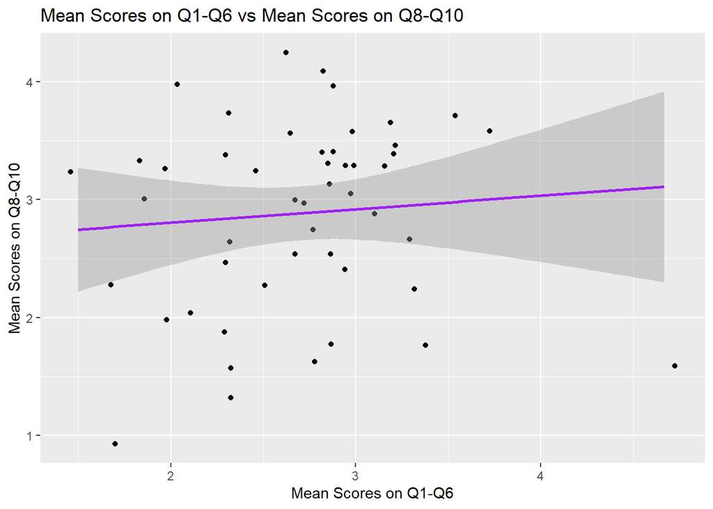

# **Analysis**

This section is used to calculate the correlations between the mean of q1:q6 and q8:q10.

```r
Q1_Q6Mean <- rowMeans(select(week8_tbl, q1:q6))
Q8_Q10Mean <- rowMeans(select(week8_tbl, q8:q10))

correlation<-cor.test(Q1_Q6Mean,Q8_Q10Mean)
correlation
```

```
##
##  Pearson's product-moment correlation
##
## data:  Q1_Q6Mean and Q8_Q10Mean
## t = 0.58309, df = 47, p-value = 0.5626
## alternative hypothesis: true correlation is not equal to 0
## 95 percent confidence interval:
##  -0.2012466  0.3574248
## sample estimates:
##        cor
## 0.08474575
```

The correlation between the two mean scores is 0.0847457. The p-value of 0.5626235 indicating that there is no statistically significant evidence to reject the null hypothesis that true correlation is equal to 0.

# **Data Export**

This section used saveRDS to export the data to the shiny folder.

```r
saveRDS(week8_tbl,"../shiny_week8/week8_tbl.rds")
```